#### `bati_type` (type de bâtiments présents)

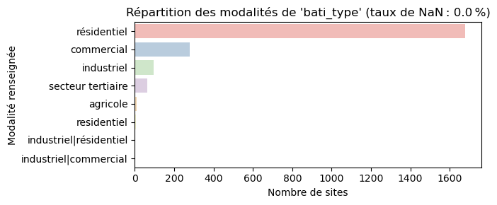

bati_nombre Exploitable

#### `bati_nombre` (nombre de bâtiments)

bati_surface Inexploitable mais critique

#### `bati_surface` (surface de plancher totale)

Similaire, très peu renseigné (on voit que dans l’exemple du standard, une friche avait 2400 m² de plancher, mais dans notre export on ne repère pas de mode significative). La plupart des sites n’ont pas cette donnée.  
**Problèmes** : On ne peut pas estimer la volumétrie du bâti existant, utile pourtant pour évaluer le potentiel de réhabilitation.  
**Causes** : Là encore, seule une extraction des données foncières (valeur locative et surface bâtie) ou des bases bâtiments pourrait fournir cette info. Non fait à ce stade hormis tests.  
**Recommandations** : Prévoir de calculer ou importer ces surfaces quand la BD des bâtiments (BDNB) sera disponible. On peut aussi obtenir des approximations en multipliant l’emprise au sol par nombre d’étages, mais c’est un travail lourd manuellement. Court terme : laisser vide plutôt que mettre des mauvaises valeurs.

bati_vacance Inexploitable

#### `bati_vacance` (état de vacance des bâtiments)

Devrait indiquer si les bâtiments sont inoccupés. Peu de données présentes. Peut-être quelques “vacant” ou “occupé partiellement” isolés. Probablement >90% manquant.  
**Problèmes** : On ne sait pas si sur une friche certains bâtiments servent encore (stockage, etc.).  
**Causes** : Là encore, il faut du travail de terrain ou des croisements (par ex. croiser avec la taxe foncière bâtie – si non imposé = vacant). Non fait sauf exceptions.  
**Recommandations** : Laisser ce champ vide tant qu’on n’a pas de données fiables, plutôt que mettre “inconnu” partout. Sur les sites où on sait des choses (via les collectivités), on peut indiquer “occupé temporairement”, etc. Mais globalement, c’est un champ à remplir manuellement au cas par cas. Au niveau national, on peut estimer qu’il y a quasi 100% de vacance sur friche, mais ce serait imprécis. Donc champ peu utilisable actuellement. On peut suggérer comme amélioration d’analyser des images satellites nocturnes pour repérer l’absence d’éclairage comme indice de vacance, mais c’est prospectif.

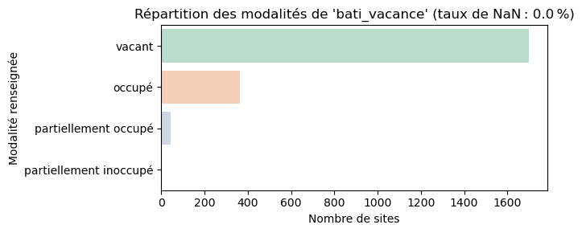

bati_patrimoine Inexploitable mais critique

#### `bati_patrimoine` (présence de bâti patrimonial)

Là aussi, très peu renseigné. Quelques friches peuvent avoir “monument inscrit” ou “présence d’un élément patrimonial” noté, mais c’est marginal.  
**Problèmes** : On ne bénéficie pas de l’indication qu’un bâtiment sur site a une valeur historique ou architecturale, ce qui pourrait orienter les projets (conservation ou pas).  
**Causes** : Cette info demande de croiser avec la liste des monuments historiques ou le PLU (certains bâtiments sont protégés). Non fait sauf si mentionné par un observatoire local.  
**Recommandations** : Croiser avec la base Mérimée (Monuments protégés) ou le patrimoine industriel inventorié, afin de taguer les friches concernées. C’est un ajout précieux pour prioriser certains sites, mais il y a du bruit possible (bâtiment protégé adjacent, etc.). Au minimum, inciter les acteurs locaux à renseigner ce champ quand ils connaissent un édifice remarquable sur le site. Pour l’instant, supposer par défaut “non renseigné = pas d’info, nécessite enquête”.

bati_etat Inexploitable mais critique

#### `bati_etat` (état de dégradation des bâtiments)

unite_fonciere_surface Exploitable

#### `unite_fonciere_surface`

```
count    2.805200e+04
mean     1.120489e+05
std      1.188390e+06
min      1.000000e+00
25%      1.554750e+03
50%      7.521000e+03
75%      3.661200e+04
max      1.340958e+08
Name: unite_fonciere_surface, dtype: float64
```

Unite fonciere surface fait partie des données les plus fournies du dataset

```
📌 Année médiane pondérée par la surface foncière : 2022.0
```

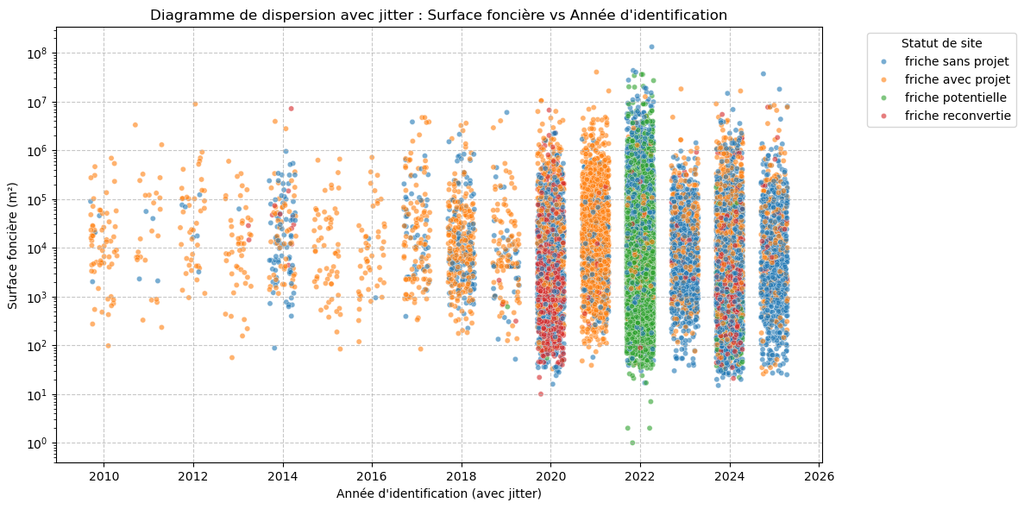

[interactive chart not shown]

unite_fonciere_refcad Exploitable